# New York Avocado Price Prediction : Time-Series Analysis

By : Syabaruddin Malik

# 1 Introduction

It is a well known fact that Millenials LOVE Avocado Toast :D . It’s also a well known fact that all Millenials live in their parents basements :( .

Clearly, they aren’t buying home because they are buying too much Avocado Toast!

Now let’s help our Millenials in New York to predict avocado prices so they can save more to enjoy more avocados!

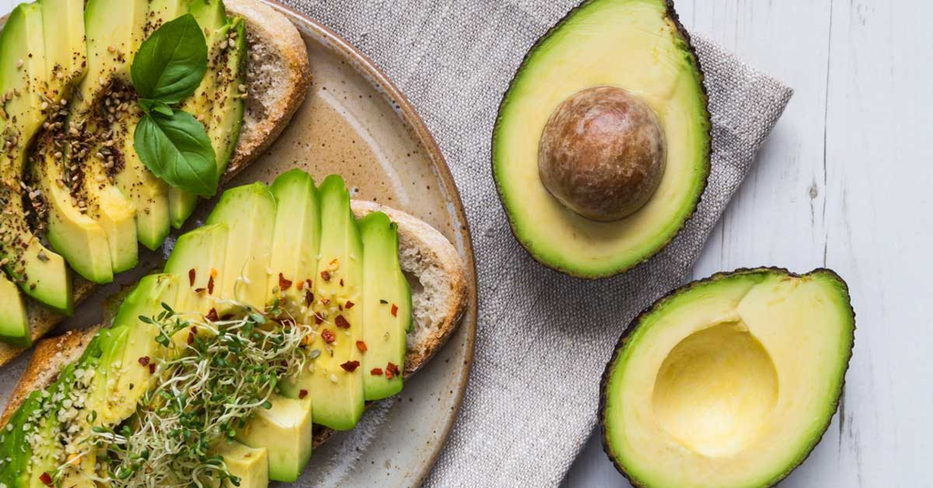

This data is downloaded from from link below:

https://www.kaggle.com/neuromusic/avocado-prices

# 2 Exploratory Data

## 2.1 Import Library

Let us import the library required.

```r
library(dplyr) # for data wrangling
library(lubridate) # to dea with date
library(padr) # for padding
library(forecast) # time series library
library(tseries) # for adf.test
library(MLmetrics) # calculate error
library(ggplot2)
```

## 2.2 Import Data

Let us import the data for the analysis.

```r
avocado <- read.csv("avocado.csv")
avocado <- avocado %>% filter(region=="NewYork") %>% select(Date,AveragePrice)
```

## 2.3 Data Pre-Processing

Our Date column is still not in Date data type. We have to change to Date data type

```r
avocado$Date <- as.Date(avocado$Date)
avocado$Date <- ymd(avocado$Date)
```

The characteristics of a Time Series object must consists of:

- an ordered structure for the period
- no missing period, and
- no missing value

Therefore, we need to do time series padding.

```r
avocado_clean <- avocado %>%
  group_by(Date) %>%
  summarise(AveragePrice=mean(AveragePrice)) %>%
  arrange(Date)

avocado_clean
```

| Date | AveragePrice |
| --- | --- |
| 2015-01-04 | 1.510 |
| 2015-01-11 | 1.685 |
| 2015-01-18 | 1.725 |
| 2015-01-25 | 1.690 |
| 2015-02-01 | 1.645 |
| 2015-02-08 | 1.530 |
| 2015-02-15 | 1.635 |
| 2015-02-22 | 1.770 |
| 2015-03-01 | 1.590 |
| 2015-03-08 | 1.630 |

[output cut: 159 more lines]

```r
colSums(is.na(avocado_clean))
```

```
#>         Date AveragePrice
#>            0            0
```

Our Dataset is ready. It is on periodic order, no missing period and no missing value.

# 3 Time Series Analysis

## 3.1 TS Object

Before we do analysis and make prediction, we have to make our data set as a Time-Series (TS) Object

```r
avocado_ts <- ts(data = avocado_clean$AveragePrice,
   start = 2015,
   frequency = 48)
```

In this section, I tried to explore whether our timeseries object has trend and seasonal properties (one-seasonal/multiseasonal).

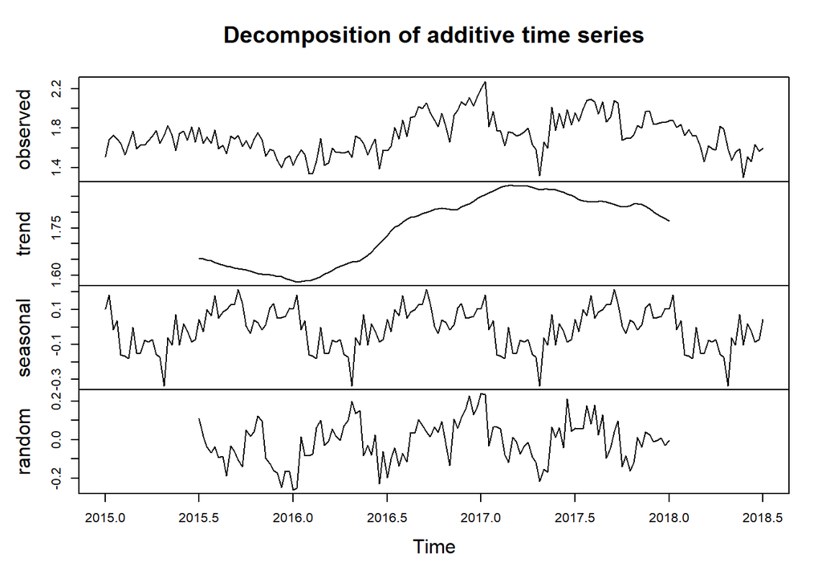

```r
avocado_deco <- avocado_ts %>%  decompose() %>% plot()
```

If we look at plot above, the data has trend and seasonality

## 3.2 Cross Validation

The cross-validation scheme for time series should not be sampled randomly, but splitted sequentially.

```r
# 24 latest week for  test
avocado_test <- tail(avocado_ts, 24)

avocado_train <- head(avocado_ts, -24)
```

## 3.3 Model Building

This time, I will compare between two of the widely used time series modeling in business and industry: Holt-Winters and Seasonal Arima. I use Holt-Winters because my data contain both seasonality and trend. I also want to compare it between seasonal Arima to check whether seasonal ARIMA can give better forecasting performance.

```r
# Holt-Winters
avocado_hw <- HoltWinters(avocado_train)
# ARIMA
avocado_arima <- auto.arima(avocado_train, seasonal = T)
```

## 3.4 Forecast & Evaluation

Now we are going to forecast and evaluate our models

```r
#forecast

avocado_hw_f <- forecast(avocado_hw,h=24)
avocado_arima_f <- forecast(avocado_arima,h=24)
```

Now let us compare our Models performance

```r
#Holts-Winter Model
accuracy(avocado_hw_f,avocado_test)
```

```
#>                       ME      RMSE        MAE          MPE      MAPE      MASE
#> Training set  0.00492317 0.1422274 0.09740765  -0.05874552  5.330022 0.4293816
#> Test set     -0.23076662 0.3121820 0.25023176 -15.19327495 16.284733 1.1030439
#>                    ACF1 Theil's U
#> Training set 0.04455499        NA
#> Test set     0.70795934  2.526663
```

```r
#Arima Model
accuracy(avocado_arima_f,avocado_test)
```

```
#>                        ME      RMSE        MAE          MPE      MAPE      MASE
#> Training set  0.004396247 0.1189256 0.09218445  -0.09417289  5.344705 0.4063573
#> Test set     -0.230409053 0.2698729 0.23197219 -14.95703282 15.039958 1.0225541
#>                     ACF1 Theil's U
#> Training set 0.002780219        NA
#> Test set     0.536553230   2.15109
```

If we look at above result, we found that our *Arima* model is the best model with lower MAPE value.